# Demo: Regression Basics

NIHES BST02

Nicole Erler, Department of Biostatistics, Erasmus Medical Center

12 February 2020

## Linear Regression

### Fitting the model

Fit a linear regression model

```r
mod <- lm(Infant.Mortality ~ Fertility + Agriculture + Education + Catholic,
          data = swiss)
```

### Model results

Get the model summary

```r
summary(mod)
```

```
##
## Call:
## lm(formula = Infant.Mortality ~ Fertility + Agriculture + Education +
##     Catholic, data = swiss)
##
## Residuals:
##     Min      1Q  Median      3Q     Max
## -8.0828 -1.3459  0.0846  1.7459  5.9609
##
## Coefficients:
##              Estimate Std. Error t value Pr(>|t|)
## (Intercept)  9.609099   4.802150   2.001  0.05188 .
## Fertility    0.147984   0.052400   2.824  0.00722 **
## Agriculture -0.014852   0.026663  -0.557  0.58047
## Education    0.073461   0.077603   0.947  0.34924
## Catholic    -0.002446   0.012853  -0.190  0.84997
## ---
## Signif. codes:  0 '***' 0.001 '**' 0.01 '*' 0.05 '.' 0.1 ' ' 1
##
## Residual standard error: 2.655 on 42 degrees of freedom
## Multiple R-squared:  0.2412, Adjusted R-squared:  0.1689
## F-statistic: 3.337 on 4 and 42 DF,  p-value: 0.01844
```

Extract the regression coefficients

```r
coef(mod)
```

```
##  (Intercept)    Fertility  Agriculture    Education     Catholic
##  9.609098835  0.147984123 -0.014851920  0.073460957 -0.002446186
```

Obtain the confidence interval

```r
confint(mod)
```

```
##                   2.5 %      97.5 %
## (Intercept) -0.08203297 19.30023064
## Fertility    0.04223708  0.25373117
## Agriculture -0.06865983  0.03895599
## Education   -0.08314788  0.23006980
## Catholic    -0.02838390  0.02349153
```

The function `confint()` also has arguments `parm` and `level` that let us specify for which parameters we want to get the confidence interval and the confidence level.

```r
confint(mod, level = 0.9, parm = -1)
```

```
##                     5 %       95 %
## Fertility    0.05985018 0.23611806
## Agriculture -0.05969765 0.02999381
## Education   -0.05706329 0.20398521
## Catholic    -0.02406375 0.01917137
```

### Model evaluation

To evaluate how well the model fits the data we can check the diagnostic plots that are obtained when plotting the model:

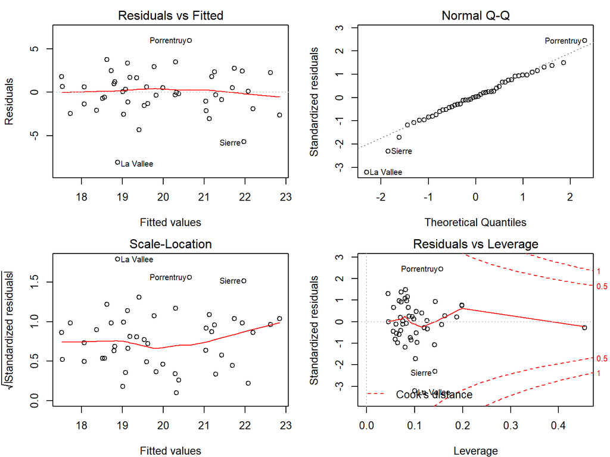

```r
par(mfrow = c(2, 2), mar = c(4, 4.2, 2, 1.3)) # graphical settings
plot(mod)
```

We can re-create some of these plots ourselves. Residuals and fitted values can be obtained from a linear regression model in two ways:

```r
mod$residuals
```

```
##   Courtelary     Delemont Franches-Mnt      Moutier   Neuveville   Porrentruy        Broye        Glane
##   0.11788965   0.50962794  -2.64684001  -1.89566052  -0.83231143   5.96090655   2.34533810   2.27411214
##      Gruyere       Sarine      Veveyse        Aigle      Aubonne     Avenches     Cossonay    Echallens
##  -0.28669095   2.46286418   2.75988554  -2.53475208   0.08459405   2.92561173   0.62911226   2.47411072
##     Grandson     Lausanne    La Vallee       Lavaux       Morges       Moudon        Nyone         Orbe
##  -0.29421044   0.60902926  -8.08284739   1.18712344  -1.13573012   3.78094783  -1.37353372  -2.43039041
##         Oron      Payerne Paysd'enhaut        Rolle        Vevey      Yverdon      Conthey    Entremont
##   1.65191881   3.49848166  -1.53497943  -2.07486658   1.71085664   3.37514362  -4.30913291   0.99959951
##       Herens     Martigwy      Monthey   St Maurice       Sierre         Sion       Boudry La Chauxdfnd
##  -1.31835765   0.32074945  -0.17526708  -0.71963554  -5.67384777  -3.02521190  -0.02465131   0.50836644
##     Le Locle    Neuchatel   Val de Ruz ValdeTravers V. De Geneve  Rive Droite  Rive Gauche
##  -2.14706376   1.81275626  -1.03630376  -0.32816185  -0.56058006   0.66110373   1.78089715
```

```r
residuals(mod)
```

```
##   Courtelary     Delemont Franches-Mnt      Moutier   Neuveville   Porrentruy        Broye        Glane
##   0.11788965   0.50962794  -2.64684001  -1.89566052  -0.83231143   5.96090655   2.34533810   2.27411214
##      Gruyere       Sarine      Veveyse        Aigle      Aubonne     Avenches     Cossonay    Echallens
##  -0.28669095   2.46286418   2.75988554  -2.53475208   0.08459405   2.92561173   0.62911226   2.47411072
##     Grandson     Lausanne    La Vallee       Lavaux       Morges       Moudon        Nyone         Orbe
##  -0.29421044   0.60902926  -8.08284739   1.18712344  -1.13573012   3.78094783  -1.37353372  -2.43039041
##         Oron      Payerne Paysd'enhaut        Rolle        Vevey      Yverdon      Conthey    Entremont
##   1.65191881   3.49848166  -1.53497943  -2.07486658   1.71085664   3.37514362  -4.30913291   0.99959951
##       Herens     Martigwy      Monthey   St Maurice       Sierre         Sion       Boudry La Chauxdfnd
##  -1.31835765   0.32074945  -0.17526708  -0.71963554  -5.67384777  -3.02521190  -0.02465131   0.50836644
##     Le Locle    Neuchatel   Val de Ruz ValdeTravers V. De Geneve  Rive Droite  Rive Gauche
##  -2.14706376   1.81275626  -1.03630376  -0.32816185  -0.56058006   0.66110373   1.78089715
```

```r
mod$fitted.values
```

```
##   Courtelary     Delemont Franches-Mnt      Moutier   Neuveville   Porrentruy        Broye        Glane
##     22.08211     21.69037     22.84684     22.19566     21.43231     20.63909     21.25466     22.62589
##      Gruyere       Sarine      Veveyse        Aigle      Aubonne     Avenches     Cossonay    Echallens
##     21.28669     21.93714     21.74011     19.03475     19.01541     19.77439     18.07089     18.72589
##     Grandson     Lausanne    La Vallee       Lavaux       Morges       Moudon        Nyone         Orbe
##     20.29421     19.59097     18.88285     18.81288     19.13573     18.61905     18.07353     17.73039
##         Oron      Payerne Paysd'enhaut        Rolle        Vevey      Yverdon      Conthey    Entremont
##     19.34808     20.30152     19.53498     18.37487     19.18914     19.12486     19.40913     18.80040
##       Herens     Martigwy      Monthey   St Maurice       Sierre         Sion       Boudry La Chauxdfnd
##     19.61836     19.07925     20.37527     18.51964     21.97385     21.12521     20.32465     19.99163
##     Le Locle    Neuchatel   Val de Ruz ValdeTravers V. De Geneve  Rive Droite  Rive Gauche
##     21.04706     21.18724     21.03630     19.82816     18.56058     17.53890     17.51910
```

```r
fitted(mod) # also: fitted.values(mod)
```

```
##   Courtelary     Delemont Franches-Mnt      Moutier   Neuveville   Porrentruy        Broye        Glane
##     22.08211     21.69037     22.84684     22.19566     21.43231     20.63909     21.25466     22.62589
##      Gruyere       Sarine      Veveyse        Aigle      Aubonne     Avenches     Cossonay    Echallens
##     21.28669     21.93714     21.74011     19.03475     19.01541     19.77439     18.07089     18.72589
##     Grandson     Lausanne    La Vallee       Lavaux       Morges       Moudon        Nyone         Orbe
##     20.29421     19.59097     18.88285     18.81288     19.13573     18.61905     18.07353     17.73039
##         Oron      Payerne Paysd'enhaut        Rolle        Vevey      Yverdon      Conthey    Entremont
##     19.34808     20.30152     19.53498     18.37487     19.18914     19.12486     19.40913     18.80040
##       Herens     Martigwy      Monthey   St Maurice       Sierre         Sion       Boudry La Chauxdfnd
##     19.61836     19.07925     20.37527     18.51964     21.97385     21.12521     20.32465     19.99163
##     Le Locle    Neuchatel   Val de Ruz ValdeTravers V. De Geneve  Rive Droite  Rive Gauche
##     21.04706     21.18724     21.03630     19.82816     18.56058     17.53890     17.51910
```

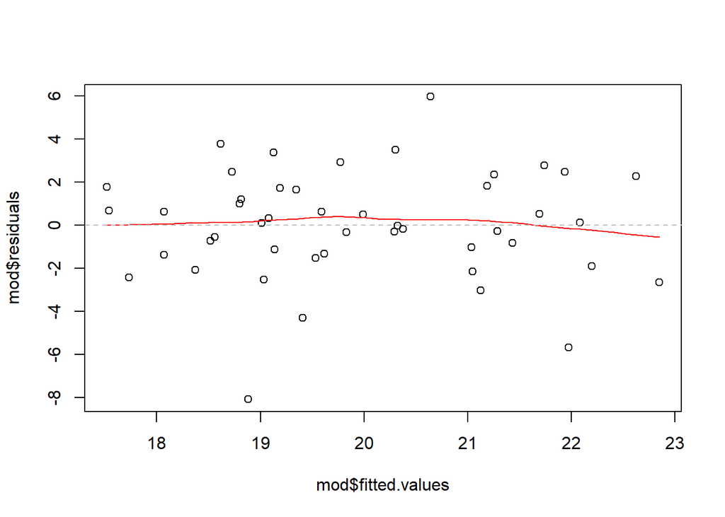

```r
scatter.smooth(mod$fitted.values, mod$residuals, lpars = list(col = 'red'))
abline(h = 0, lty = 2, col = 'grey')
```

#### QQ-plot

To create a normal QQ-plot we plot the quantiles of the standardized residuals against the quantiles of a normal distribution:

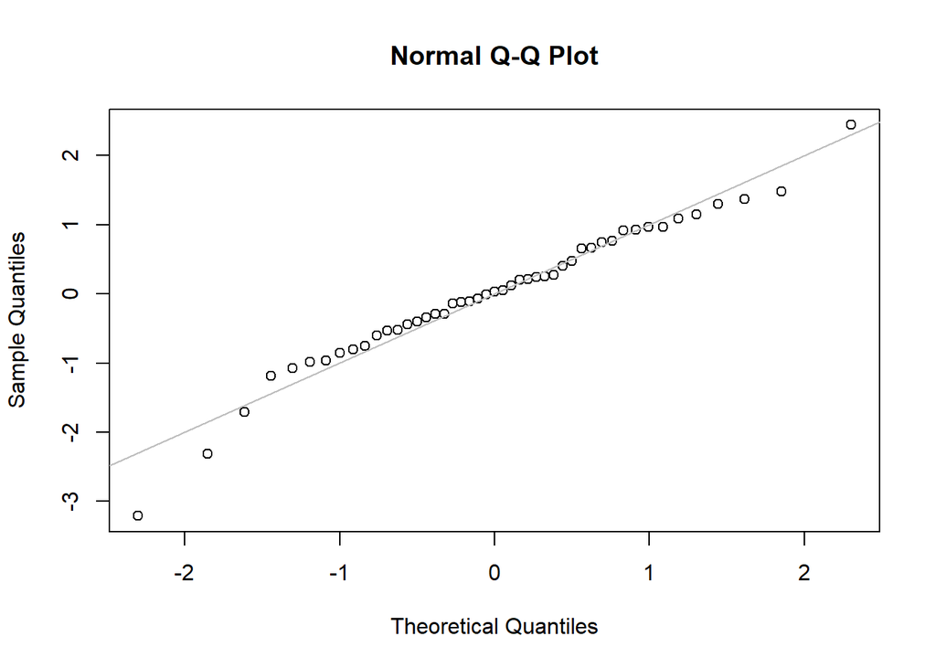

```r
qqnorm(rstandard(mod))
abline(a = 0, b = 1, lty = 1, col = 'grey')
```

## Logistic Regression

```r
mod2 <- glm(case ~ age + education + spontaneous, data = infert, family = binomial())
summary(mod2)
```

```
##
## Call:
## glm(formula = case ~ age + education + spontaneous, family = binomial(),
##     data = infert)
##
## Deviance Residuals:
##     Min       1Q   Median       3Q      Max
## -1.5938  -0.7097  -0.6580   0.9013   1.8438
##
## Coefficients:
##                  Estimate Std. Error z value Pr(>|z|)
## (Intercept)      -1.64883    1.23543  -1.335    0.182
## age               0.01280    0.02925   0.438    0.662
## education6-11yrs -0.11687    0.69856  -0.167    0.867
## education12+ yrs -0.16938    0.71496  -0.237    0.813
## spontaneous       1.07697    0.19835   5.430 5.64e-08 ***
## ---
## Signif. codes:  0 '***' 0.001 '**' 0.01 '*' 0.05 '.' 0.1 ' ' 1
##
## (Dispersion parameter for binomial family taken to be 1)
##
##     Null deviance: 316.17  on 247  degrees of freedom
## Residual deviance: 283.40  on 243  degrees of freedom
## AIC: 293.4
##
## Number of Fisher Scoring iterations: 4
```

Note: the coefficients are on the log odds ratio scale. The functions `coef()` and `confint()` also work on GLMs.

### Changing parts of the model

To re-fit the model with a small change, the function `update()` is useful:

```r
mod2b <- update(mod2, formula = . ~ . - education)
```

In `update()` we specify the model we want to update and only those arguments that need to be changed. In our case, the model formula. Using `.` we can specify to keep parts of the formula the same. This allows us to “subtract” `education` from the original formula. `update()` also works for other types of objects (not just regression models):

```r
formula(mod2)
```

```
## case ~ age + education + spontaneous
```

```r
update(formula(mod2), . ~ . - education)
```

```
## case ~ age + spontaneous
```

### Comparing Models

To check if `education` is needed in the model, we can use a likelihood ratio test to compare the models with and without `education`. This is implemented in the function `anova()`.

```r
anova(mod2, mod2b, test = "LRT")
```

```
## Analysis of Deviance Table
##
## Model 1: case ~ age + education + spontaneous
## Model 2: case ~ age + spontaneous
##   Resid. Df Resid. Dev Df  Deviance Pr(>Chi)
## 1       243     283.40
## 2       245     283.47 -2 -0.067896   0.9666
```

To compare non-nested models (where one model is not a special case of the other model) we can use the `AIC()` or `BIC()`:

```r
mod3 <- update(mod2b, formula = . ~ . - age + induced)

AIC(mod3, mod2b)
```

```
##       df     AIC
## mod3   3 285.612
## mod2b  3 289.469
```